Teoria Moderna do Portfólio: Fronteira Eficiente de Markowitz

Gustavo Prado

10 de Agosto de 2021

## *Resumo*

Material produzido para o curso: *Gestão de Portfólios usando o R da Escola de Finanças Quantitativas Quant School*. A estrutura desse relatório parte de um problema prático do mercado financeiro que é solucionado utilizando programação, com base nos conceitos de fronteira eficiente de Markowitz, que será construída de forma empírica via simulações de Monte Carlo e, ainda, com auxílio do pacote `ggplot2` para visualização dos dados obtidos via simulação. Além disso, vale ressaltar, que a motivação é introduzir conceitos básicos da Teoria Moderna do Portfólio e teoria das probabilidades, sendo este um trabalho introdutório para fins de fixação de conteúdo, que não irá se aprofundar em demonstrações matemáticas e condições de pressupostos do modelo. O problema será: como construir um portfólio de investimentos otimizado com base no conceito do binômio **risco-retorno** (segundo a Teoria Moderna do Portfólio de Markowitz). Algumas premissas do modelo são:

- Investidores são racionais(avessos ao risco);
- Princípio da diversificação para otimizar carteiras de investimento;
- Normalidade dos retornos;
- Volatilidade medida pelo desvio padrão.

$$\cdots$$

## *Metodologia*

A estrutura dos códigos desse relatório será da seguinte forma: o primeiro passo será a utilização do pacote `quantmod` para obtenção dos dados do site *Yahoo Finance*. Através desses dados serão criadas funções. A primeira delas irá armazenar em uma lista de *data frames* em que cada índice dessa lista representa as informações referente a cada ativo financeiro. A proposta será selecionar 4 ativos e armazenar as informações em uma matriz de preços e, posteriormente, uma matriz de retornos. Em uma etapa seguinte será obtido o retorno médio dos ativos e a matriz de covariância, através da matriz de retornos. Munidos dessas duas informações dos ativos do portfólio, nesta etapa, será possível calcular via processo de otimização matemática os pesos(de cada ativo) maximizados. A otimização nos retorna os pesos de cada ativo financeiro no nosso portfólio, dado um valor $\lambda$ (lambda) que representa a utilidade do investidor (no nosso contexto irá representar o grau de aversão ao risco do investidor). Essa valor $\lambda$ representa um dos parâmetros da [função de custo](https://pt.wikipedia.org/wiki/Fun%C3%A7%C3%A3o_de_perda), que será a função que vamos otimizar com a função `optim` do R. Nessa mesma etapa da otimização, também faremos uma simulação de Monte Carlo para construir a fronteira eficiente de forma empírica, através de funções que irão retornar o valor numérico do retorno esperado do portfólio e da volatilidade(desvio padrão do portfólio). Alinhando os dados da otimização e da simulação, estaremos na etapa final do processo, conseguindo mostrar visualmente onde essas carteiras otimizadas estariam na fronteira eficiente simulada.

OBS.: Os pesos de cada ativo do portfólio devem somar 1 e restrição *long-only* (como o próprio nome diz, apenas comprados, apostando sempre na valorização das ações que investe).

$$\cdots$$

## *Conceitos teóricos necessários*

**Teoria Moderna do Portfólio (TMP)**

A teoria moderna do portfólio considera a rentabilidade do ativo como uma Variável Aleatória(v.a.), e a carteira de investimentos como uma combinação ponderada de ativos financeiros. Uma v.a. terá duas estatísticas fundamentais para construção do modelo: valor esperado e variância. Dentro da TMP o valor esperado será atribuído o retorno esperado ou rentabilidade esperada do ativo, e o desvio padrão(raiz quadrada da variância), será o risco/volatilidade. Para cada nível de retorno de uma carteira é possível variar os pesos dos ativos individuais para determinar a carteira com o menor risco. Estas carteiras possuem o menor desvio padrão de todas as carteira com um dado retorno e são chamadas de *carteira com variância mínima*. Essas carteiras de variância mínima irão formar a *fronteira eficiente*. Assumindo um investidor avesso ao risco, dado um nível de tolerância ao risco, a carteira ótima sempre irá pertencer a fronteira eficiente, ignorando as carteiras que não pertencem a fronteira. Esse resultado é possível ser obtido de forma analítica, aceitando algumas premissas para que o modelo, dada uma aceitação ao risco, seja maximizado o retorno esperado. Essa solução é possível pois a utilização da volatilidade como medida de risco nos trás boas propriedades matemáticas, sendo assim possível utilizar técnicas de otimização.

**Probabilidade e Variáveis Aleatórias**

Alguns resultados da teoria de probabilidades serão necessários para uma compreensão total do problema. Aqui esses resultados não serão demonstrados, apenas enunciados para conhecimento e revisão rápida.

1. O valor esperado de uma combinação linear de variáveis aleatórias é a combinação linear dos seus valores esperados.

$$\mathbb{E}(aX + bY) = a\mathbb{E}(X) + b\mathbb{E}(Y)$$

2. A covariância entre $X$ e $Y$ é igual a esperança do produto menos o produto das esperanças:

$$Cov(X,Y) = \mathbb{E}(XY) - \mathbb{E}(X)\mathbb{E}(Y)$$

3. O coeficiente de correlação entre $X$ e $Y$ é definido por:

$$\rho_{XY} = \frac{Cov(X,Y)}{\sigma_X \sigma_Y}$$

Lembre-se: $\sigma_X = \sqrt{Var(X)}$ é o desvio padrão da variável aleatória $X$.

4. A variância da soma de $X$ e $Y$:

$$Var(aX+bY) = a^2Var(X)+b^2Var(Y)+2 a b\cdot Cov(X,Y)$$

**Notações de probabilide em finanças**

Os resultados teóricos mencionados acima são fundamentais para a compreensão do problema no universo de finanças. Agora vamos abstrair alguns desses resultados com a nomenclatura usual de finanças.

1. O valor esperado do retorno de um portfólio com dois ativos(Ativo **E** e Ativo **D**). A fração investida em **E** é $w_e$. Fração investida em **D** é $w_d$. O retorno total do portfólio é dado por:

$$R_p = w_dR_d + w_eR_e$$

$$\mathbb{E}(R_p) = \mathbb{E}(w_dR_d + w_eR_e) = w_d\mathbb{E}(R_d) +
w_e\mathbb{E}(R_e)$$

Ou seja, o retorno do portfólio é a média ponderada dos retornos dos ativos que o compõem.

2. A variância do portfólio é definido por:

$$Var(R_p) = \sigma^2_p = w_d^2 \sigma^2_d+w_e^2 \sigma^2_e+2 w_d w_e\cdot
Cov(R_d,R_e)$$

Lembre-se: $\sigma_p$ é o desvio padrão/risco do portfólio.

**Variância do portfólio em notação matricial**

Essa notação é especialmente interessante pois permite que calculemos a variância do portfólio para $n$ ativos sem que nos preocupemos com fórmulas.

$$\sigma^2_p = \begin{bmatrix}
w_d \\
w_e \\
\end{bmatrix}\times\begin{bmatrix}
Var(R_d) & Cov(R_d, R_e) \\
Cov(R_d, R_e) & Var(R_e) \\
\end{bmatrix}\times\begin{bmatrix}
w_d & w_e \\
\end{bmatrix}$$

$$\cdots$$

## *Pacotes usados*

```r
if(!require("pacman")) install.packages("pacman")

pacman::p_load(tidyverse,
               magrittr,
               ggthemes,
               gridExtra,
               kableExtra,
               corrplot,
               gganimate,
               quantmod,
               dplyr)
```

$$\star$$

## *Manipulando dados*

Utilizaremos nessa simulação **4 ativos financeiros**. Sendo eles:

- Dólar;
- Ações da Ambev;
- Ações da Vale;
- Ações do Itáu;

```r
# Construindo vetor de ativos e nomeando
asset_vec <- c(Dolar ="BRL=X",
               Ambev = "ABEV3.SA",
               Vale = "VALE3.SA",
               Itau = "ITUB4.SA")
```

### Bases de dados

Abaixo vamos criar uma função que gera uma lista de bases de dados financeiros utilizando a API do Yahoo! Finance. Serão 4 *data.frames* e cada um deles representa os ativos escolhidos acima. Esses *data.frames* serão armazenados em uma lista.

```r
# Criando funcao que baixa e junta as bases de dados em unico objeto
gen_df_list <- function(asset_vec) {
    # cria uma lista vazia
    df_list <- list()

    for(i in 1:length(asset_vec)){
        # extraindo o i-esimo simbolo do ativo
        asset <- asset_vec[i]
        # extraindo o i-esimo nome do ativo
        asset_name <- names(asset_vec)[i]
        df_list[[asset_name]] <- getSymbols(asset, auto.assign = FALSE) %>%
            # transforma em um data frame
            data.frame(stringsAsFactors = FALSE)

        # renomeando os nomes das colunas
        colnames(df_list[[asset_name]]) <- c("open", "high", "low",
                                        "close", "volume", "adjusted")
    }
    return(df_list)
}

# rodando a funcao criada
df_list <- gen_df_list(asset_vec)
```

$$\cdots$$

### Matriz de preços

Processo para criação da função da matriz de preços.

- Criação da função que condensa as bases de dados em apenas uma matriz.
- Descobrimos qual a maior base para inicializar o processo de *merge*.
- Iteramos nas bases extraindo a coluna *“adjusted”* para a matriz final.
- Renomeamos as variáveis para manter os nomes convenientes.

Cada linha será uma data e cada coluna um ativo que foi armazenado em `df_list`.

```r
# funcao que gera uma unica matriz de precos
gen_price_matrix <- function(df_list) {

    # Buscando qual a maior base dos dados disponivel
    # criando um vetor numerico vazio
    nrow_vec <- numeric()
    # iterando em cada base de dados para ver quantas linhas cada uma tem
    for(df in df_list){
        # incrementando o vetor com o num de linhas do df
        nrow_vec <- c(nrow_vec, nrow(df))
    }

    # obtendo o indice da maior base de dados
    max_index <- which.max(nrow_vec)

    # criando vetor de datas para indexar a base de precos
    date_vec <- df_list[[max_index]] %>%
        row.names() %>%
        as.Date()

    # criando data frame apenas com colunas de datas
    price_matrix <- data.frame(date = date_vec,
                               stringsAsFactors = FALSE)

    # iterando em cada base de dados do 'df_list'
    for(df in df_list){
        # a cada iteracao um data frame temporario ira ser criado
        temp_df = data.frame(date = as.Date(row.names(df)),
                             price = df$adjusted,
                             stringsAsFactors = FALSE)

        price_matrix <- dplyr::full_join(price_matrix, temp_df, by = "date")
    }

    # renomeando as colunas da matrix de precos para carregar a nomenclatura de antes
    names(price_matrix) <- c("date", names(df_list))
    return(price_matrix)
}


price_matrix <- gen_price_matrix(df_list)
```

Obtendo algumas medidas de resumo abaixo.

```r
summary(price_matrix)
```

```
##       date                Dolar           Ambev             Vale
##  Min.   :2007-01-01   Min.   :1.534   Min.   : 1.832   Min.   :  6.022
##  1st Qu.:2010-10-25   1st Qu.:1.898   1st Qu.: 5.021   1st Qu.: 19.502
##  Median :2014-08-18   Median :2.401   Median :12.252   Median : 24.374
##  Mean   :2014-08-17   Mean   :2.967   Mean   :10.862   Mean   : 30.212
##  3rd Qu.:2018-06-11   3rd Qu.:3.793   3rd Qu.:15.573   3rd Qu.: 34.421
##  Max.   :2022-04-05   Max.   :5.886   Max.   :21.440   Max.   :102.328
##                       NA's   :34      NA's   :201      NA's   :201
##       Itau
##  Min.   : 4.489
##  1st Qu.: 9.916
##  Median :12.557
##  Mean   :16.403
##  3rd Qu.:23.423
##  Max.   :35.667
##  NA's   :201
```

```r
glimpse(price_matrix)
```

```
## Rows: 3,982
## Columns: 5
## $ date  <date> 2007-01-01, 2007-01-02, 2007-01-03, 2007-01-04, 2007-01-05, 200~
## $ Dolar <dbl> 2.1325, 2.1310, 2.1345, 2.1390, 2.1470, 2.1465, 2.1490, 2.1496, ~
## $ Ambev <dbl> NA, 2.331448, 2.319062, 2.319062, 2.276209, 2.316546, 2.299326, ~
## $ Vale  <dbl> NA, 16.77972, 15.95870, 15.70213, 15.03504, 15.59950, 15.20182, ~
## $ Itau  <dbl> NA, 8.032455, 8.080679, 8.003718, 7.695889, 7.862112, 7.693832, ~
```

$$\cdots$$

### Matriz de retornos

A matriz de retornos é feita de forma simples. Vamos dividir o preço de um dia pelo preço do dia anterior.

```r
# funcao que calcula a matriz de retorno
gen_return_matrix <- function(price_matrix, remove_date = TRUE){
    # usando price_matrix para servir de molde (migrado as dimensoes)
    return_matrix <- price_matrix
    # limpando informacoes da return_matrix menos a coluna de data
    return_matrix[,-1] <- NA
    # operacao vetorizada de divisao de um num pelo seu anterior
    return_matrix[-1,-1] <- price_matrix[-1,-1]/price_matrix[-nrow(price_matrix),-1] - 1
    # retirando os dados faltantes
    return_matrix <- na.omit(return_matrix)
    # removendo data
    if(remove_date){
        return_matrix <- return_matrix %>%
            select(-date)
    }
    return(return_matrix)
}


# rodando a funcao
return_matrix <- gen_return_matrix(price_matrix, remove_date = FALSE)
```

Abaixo podemos verificar que os dados começam em **Janeiro de 2007**. Então conseguimos garantir dados de longo prazo, para a nossa simulação da fronteira eficiente. Caso os ativos escolhidos fossem recentes e não tivessem muitos dados, muito provavelmente a simulação não iria refletir a teoria.

```r
head(return_matrix)
```

```
##         date         Dolar        Ambev        Vale          Itau
## 3 2007-01-03  0.0016424214 -0.005312578 -0.04892965  0.0060036440
## 4 2007-01-04  0.0021082221  0.000000000 -0.01607725 -0.0095240759
## 5 2007-01-05  0.0037400655 -0.018478592 -0.04248380 -0.0384607504
## 6 2007-01-08 -0.0002328831  0.017721132  0.03754297  0.0215989342
## 7 2007-01-09  0.0011646867 -0.007433481 -0.02549338 -0.0214039179
## 8 2007-01-10  0.0002791996 -0.002145846  0.03797474  0.0004001907
```

$$\cdots$$

### Matriz de covariâncias

Essa matriz que vamos construir representa como os ativos se relacionam ao longo do tempo, nos fornecendo as medidas de dispersão.

```r
# vamos precisar remover as datas
return_matrix <- gen_return_matrix(price_matrix)

# funcao que cria a matriz de covariancia
gen_cov_matrix <- function(return_matrix){
    cov(return_matrix, use = "pairwise.complete.obs")
}

cov_matrix <- gen_cov_matrix(return_matrix)
options(scipen = 999)
```

A matriz apresentada a seguir é chamada de matriz de variâncias e covariâncias. Na diagonal da matriz temos as variâncias de cada uma das variáveis.

```r
var(return_matrix) %>%
    kbl() %>%
        kable_classic_2(full_width = F)
```

|  | Dolar | Ambev | Vale | Itau |
| --- | --- | --- | --- | --- |
| Dolar | 0.0001472 | -0.0000228 | -0.0000379 | -0.0000299 |
| Ambev | -0.0000228 | 0.0003086 | 0.0001559 | 0.0001747 |
| Vale | -0.0000379 | 0.0001559 | 0.0007362 | 0.0002926 |
| Itau | -0.0000299 | 0.0001747 | 0.0002926 | 0.0005177 |

$$\cdots$$

## *Retorno e risco do portfólio*

### Retorno

Abaixo vamos verificar o retorno anualizado por ativo da nossa carteira de investimentos.

```r
gen_average_return <- function(return_matrix){
    average_returns <- colMeans(return_matrix, na.rm = TRUE)
    return(average_returns)
}

expected_returns <- gen_average_return(return_matrix)

expected_returns <- expected_returns + 1
expected_returns <- expected_returns^252
expected_returns <- expected_returns - 1
expected_returns <- expected_returns*100
expected_returns <- round(expected_returns, 2)

expected_returns
## Dolar Ambev  Vale  Itau
##  5.93 14.34 28.29 14.02
```

Agora, a próxima função criada irá retornar a rentabilidade do portfólio a partir da nossa matriz de retornos e um vetor de pesos(inicialmente vamos deixar os pesos iguais para cada ativo). Note que o retorno é apenas um número.

```r
# funcao para calcular a o retorno diario de um portfolio
calc_pf_return_vec <- function(return_matrix, weights){
    # garantindo formato de matriz
    return_matrix <- as.matrix(return_matrix)
    weights <- matrix(weights, ncol = 1)

    # multiplicacao matrizes
    return_vec <- return_matrix %*% weights

    # garantindo o formato de vetor
    return_vec <- as.numeric(return_vec)
    return(return_vec)
}


# utilizando a funcao para criar o vetor de retornos(pesos = 1/n)
return_vec <- calc_pf_return_vec(return_matrix, weights = rep(1/length(asset_vec),
                                                              length(asset_vec)))

# unificando todos os retornos em um retorno do portfolio
# criando uma funcao com argumento definido por padrao
calc_pf_return <- function(return_vec, annualize = TRUE){
    # poderia fazer de outra maneira mas omitir nesse caso sera suficiente
    return_vec <- na.omit(return_vec)
    return_total <- prod(1 + return_vec) - 1
    if(annualize){
        n <- length(return_vec)
        return_total <- (return_total - 1)^(252/n) - 1
    }
    return(return_total)
}


# executando o calculo do retorno do portfolio
pf_return <- calc_pf_return(return_vec)
pf_return
```

[output not shown]

$$\cdots$$

### Volatilidade

Aproveitando que visualizamos a tabela para matriz de covariâncias, vamos verificar a **matriz de correlação de Pearson** entre os ativos logo abaixo. Como o valor de correlação varia no intervalo de -1 a 1, ganhamos a capacidade de interpretar se os dados se relacionam linearmente. Note que a matriz gerada é simétrica, assim como a matriz de covariâncias. Portanto podemos visualizar apenas a diagonal inferior.

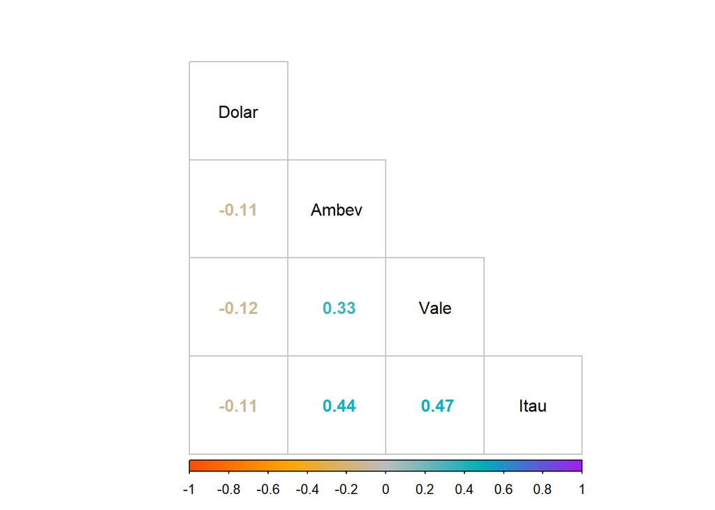

```r
col1 <- colorRampPalette(c("#FC4E07", "orange", "gray", "#00AFBB", "purple"))

corrplot(cor(return_matrix), method = "number", type = "lower", tl.pos = "d", tl.col = "black", col = col1(100))
```

De forma parecida como fizemos para a rentabilidade do portfólio, agora vamos criar a função que nos retorna a volatilidade do portfólio de investimentos, a partir da matriz de covariâncias e os pesos. Note que os pesos continuam igualmente distribuídos por enquanto, e o resultado é um valor numérico.

```r
# calculando a variancia do portfolio
calc_pf_vol <- function(cov_matrix, weights, annualize = TRUE){
    weights = matrix(weights, ncol = 1)
    cov_matrix <- as.matrix(cov_matrix)
    pf_variance <- t(weights) %*% cov_matrix %*% weights
    pf_vol <- sqrt(pf_variance)

    if(annualize){
        pf_vol <- (pf_vol) * sqrt(252)
    }
    pf_vol <- as.numeric(pf_vol)
    return(pf_vol)
}


# executando o calculo da volatilidade
weights = rep(1/length(asset_vec), length(asset_vec))
pf_vol <- calc_pf_vol(cov_matrix, weights)
pf_vol
```

```
## [1] 0.209049
```

$$\cdots$$

## *Visualização dos dados e otimização*

### Fronteira Eficiente Empírica

Nessa etapa do procedimento iremos utilizar o Método de Monte Carlo para contruir a nossa fronteira eficiente de forma empírica. O método pode ser definido como qualquer método de uma classe de métodos estatísticos que se baseiam em amostragens aleatórias massivas para obter resultados numéricos. Ou seja, a ideia seria simular inúmeras carteiras de investimento com os pesos diferentes, e marcando no gráfico de Risco X Retorno os pontos que representam o portfólio com esses pesos. Nessa simulação vamos sortear os pesos dos ativos **25mil** vezes e plotar no gráfico.

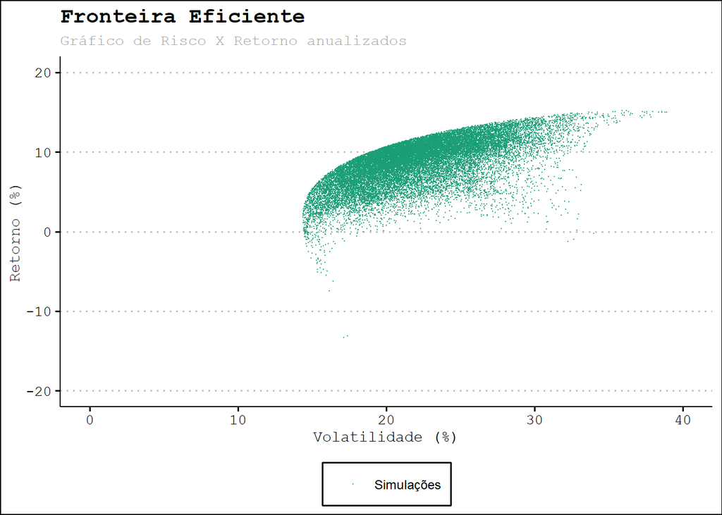

```r
# plotando risco-retorno
set.seed(1914)
reps = 25000
vol_pf_vec <- numeric()
return_pf_vec <- numeric()
for(rep in 1:reps){
    # pesos aleatorios
    weights <- runif(length(asset_vec), min = 0, max = 1)
    weights <- weights/sum(weights)

    # calculando retorno do portfolio
    return_vec <- calc_pf_return_vec(return_matrix, weights)
    pf_return <- calc_pf_return(return_vec)
    return_pf_vec <- c(return_pf_vec, pf_return)

    # calculando variancia do portfolio
    pf_vol <- calc_pf_vol(cov_matrix, weights)
    vol_pf_vec <- c(vol_pf_vec, as.numeric(pf_vol))
}


plot_pf <- ggplot(mapping = aes(x = vol_pf_vec * 100,
                                y = return_pf_vec * 100,
                                color = "Simulações")) +
    geom_point(size = .025, alpha = .8) +
    xlim(0, 40) +
    ylim(-20, 20) +
    ggtitle("Fronteira Eficiente") +
    labs(y = "Retorno (%)",
         x = "Volatilidade (%)",
         subtitle = "Gráfico de Risco X Retorno anualizados",
         color = "Legenda")  +
    theme_clean(base_size = 13,
            base_family = "mono") +
    theme(legend.title = element_blank(),
          legend.position = "bottom",
          legend.text = element_text(size=9),
          plot.subtitle = element_text(size = 10.5, color = "#A9A9A9")) +
    scale_color_brewer(palette = "Dark2")
plot_pf
```

$$\cdots$$

### Otimização

Agora que vimos a construção da fronteira eficiente, a próxima pergunta seria: quais portfólios estão justamente na melhor alocação no quesito Risco X Retorno? A otimização irá responder essa pergunta. Nesse processo, usaremos a função `optim` do R com o algoritmo do método (L-BFGS-B) de otimização.

A função que será maximizada é dada por:

Chamaremos essa função de função de custo. Como exemplo ilustrativo usaremos o valor de $\lambda = 0.01$ e verificar onde esse portfólio se localiza no meio de todas essas simulações que realizamos.

```r
# encontrando os portfolios mais eficientes
loss_func <- function(weights, exp_return_vec, cov_matrix, lambda){
    weights <- weights/sum(weights)
    out <- weights %*% exp_return_vec - (.5)*(lambda)*calc_pf_vol(cov_matrix, weights)
    return(-out)
}

gen_optim_weights <- function(weights, loss_func, return_matrix, lambda){
    results <- optim(par = weights,
                     fn = loss_func,
                     exp_return_vec = gen_average_return(return_matrix),
                     cov_matrix = gen_cov_matrix(return_matrix),
                     lambda = lambda,
                     method = "L-BFGS-B",
                     upper = rep(1, length(weights)),
                     lower = rep(0, length(weights)))
    optim_weights <- results$par/sum(results$par)
    return(optim_weights)
}


initial_weights <- c(.25, .25, .25, .25)
optim_weights <- gen_optim_weights(weights = initial_weights,
                                   loss_func = loss_func,
                                   return_matrix = return_matrix,
                                   lambda = 0.01)
```

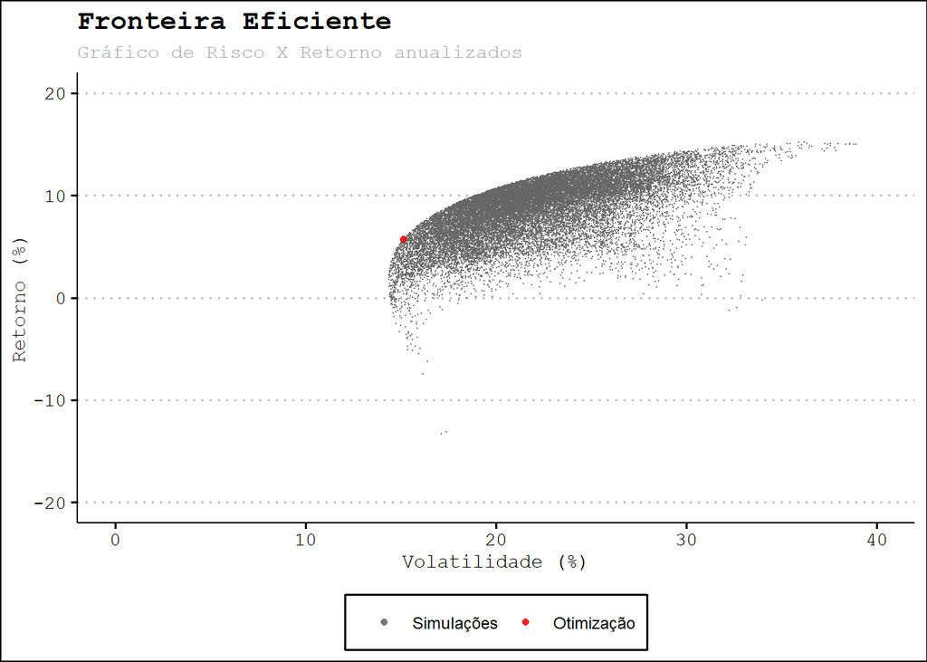

```r
pf_vol <- calc_pf_vol(cov_matrix, optim_weights)

return_vec <- calc_pf_return_vec(return_matrix, optim_weights)
pf_return <- calc_pf_return(return_vec)

plot_pf2 <- ggplot(mapping = aes(x = vol_pf_vec * 100,
                                 y = return_pf_vec * 100,
                                 color = "Simulações")) +
    geom_point(size = .025, alpha = .75) +

    geom_point(mapping = aes(x = pf_vol * 100,
                             y = pf_return * 100,
                             color = "Otimização"),
               size = 1.35, alpha = .85) +

    xlim(0, 40) +
    ylim(-20, 20) +
    ggtitle("Fronteira Eficiente") +
    labs(y = "Retorno (%)",
         x = "Volatilidade (%)",
         subtitle = "Gráfico de Risco X Retorno anualizados",
         color = "Legenda") +

    scale_color_manual(values = c(
        "Simulações" = "gray40",
        "Otimização" = "red"
    )) +
    theme_clean(base_size = 13,
            base_family = "mono") +
    theme(legend.title = element_blank(),
          legend.position = "bottom",
          legend.text = element_text(size=9),
          plot.subtitle = element_text(size = 10.5, color = "#A9A9A9"))
plot_pf2
```

$$\cdots$$

### Alocação da carteira ótima

Vimos que de fato o portfólio otimizado pertence a fronteira eficiente. O próximo questionamento seria: nesse universo dos 4 ativos que estamos trabalhando, dado o valor de $\lambda$, qual o percentual que cada ativo possui na carteira? Abaixo um gráfico de setores representa a fatia de cada ativo nessa carteira de investimento.

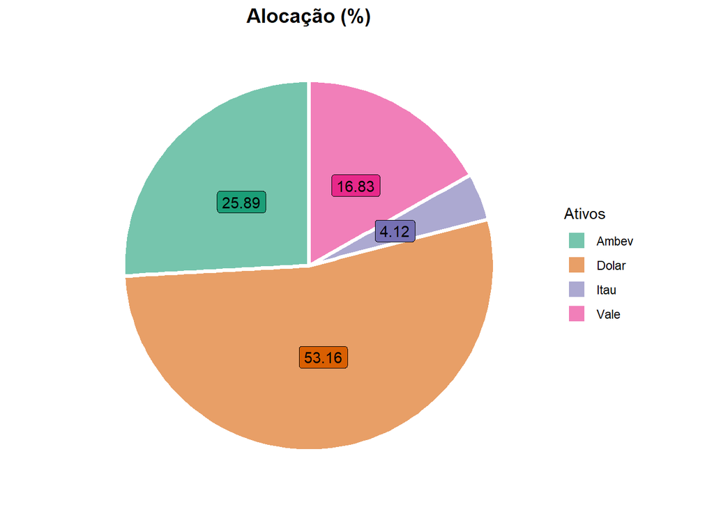

```r
blank_theme <- theme_minimal()+
  theme(
  axis.title.x = element_blank(),
  axis.title.y = element_blank(),
  panel.border = element_blank(),
  panel.grid=element_blank(),
  axis.ticks = element_blank(),
  plot.title=element_text(size=14, face="bold")
  )

pie_chart <- ggplot(mapping = aes(x = "",
                                  y = optim_weights,
                                  fill = names(return_matrix))) +
    geom_bar(width = 1,
             stat = "identity",
             color = "white",
             alpha = 0.6,
             size = 1.35) +
    coord_polar("y", start = 0) +

    geom_label(aes(label = round(optim_weights * 100, 2)),
             position = position_stack(vjust = 0.5),
             show.legend = FALSE) +

    ggtitle("Alocação (%)") +
    labs(x = "",
         y = "",
         fill = "Ativos") +
    blank_theme +

    theme(axis.text = element_blank(),
          axis.line = element_line(colour = "white"),
          plot.title = element_text(hjust = 0.5)) +
    scale_fill_brewer(palette = "Dark2")
pie_chart
```

> - Carteira otimizada: Fronteira eficiente e alocação.

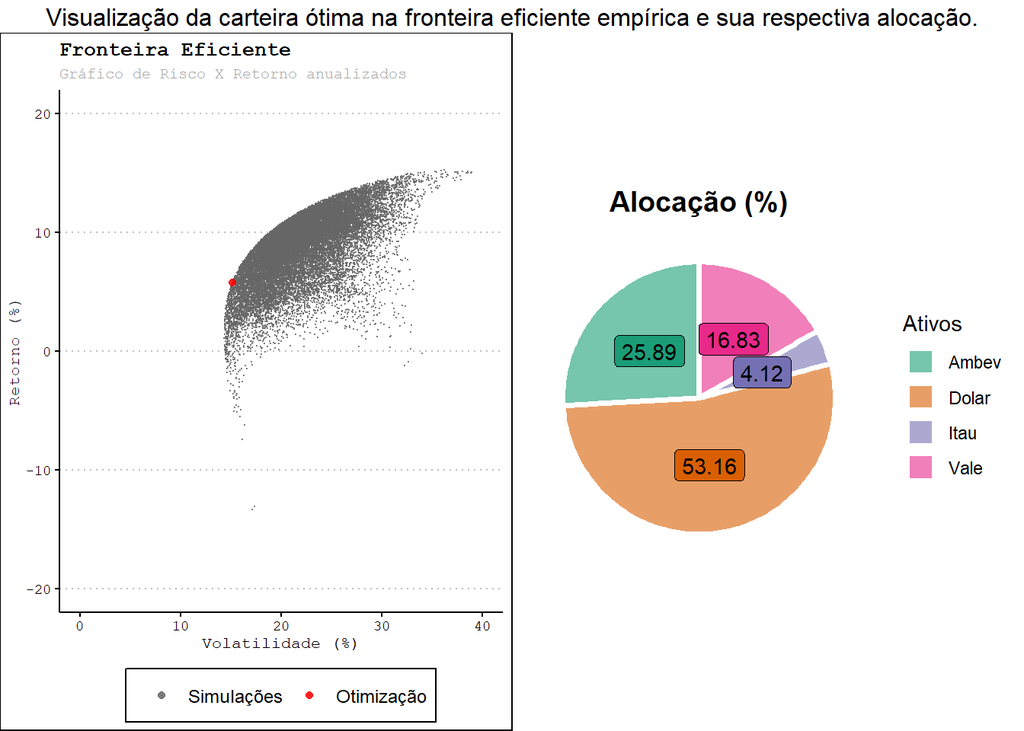

$$\cdots$$

## *Visualização animada dos dados*

Uma maneira de observar o comportamento das carteira otimizadas no gráfico da fronteira eficiente seria variando o valor de $\lambda$, que representa o nível de aversão a risco do investidor. No R temos o pacote `gganimate` que possui um recurso que possibilita a criação de gráficos com animações. Abaixo iremos usar esse pacote e verificar a posição da carteira ótima conforme o valor de $\lambda$ varia.

```r
pf_vol <- numeric()
pf_return <- numeric()

lambda_vec <- seq(from = 0.001, to = .05, by = 0.001)
for(lambda in lambda_vec){
    initial_weights <- c(.25, .25, .25, .25)
    optim_weights <- gen_optim_weights(weights = initial_weights,
                                       loss_func = loss_func,
                                       return_matrix = return_matrix,
                                       lambda = lambda)

    pf_vol_un <- calc_pf_vol(cov_matrix, optim_weights)
    pf_vol <- c(pf_vol, as.numeric(pf_vol_un))

    return_vec <- calc_pf_return_vec(return_matrix, optim_weights)
    pf_return_un <- calc_pf_return(return_vec)
    pf_return <- c(pf_return, pf_return_un)
}

table <- data.frame(volatility = pf_vol,
                     return = pf_return,
                     lambda = lambda_vec,
                     stringsAsFactors = FALSE)

plot_pf2 <- ggplot(mapping = aes(x = vol_pf_vec * 100,
                                 y = return_pf_vec * 100,
                                 color = "Simulações")) +
    geom_point(size = .025, alpha = 0.75) +

    xlim(0, 40) +
    ylim(-20, 20) +
    ggtitle("Fronteira Eficiente") +
    labs(y = "Retorno (%)",
         x = "Volatilidade (%)",
         subtitle = "Gráfico de Risco X Retorno anualizados",
         color = "Legenda") +

    theme_clean(base_size = 13,
            base_family = "mono") +
    theme(legend.title = element_blank(),
          legend.position = "bottom",
          legend.text = element_text(size=9),
          plot.subtitle = element_text(size = 10.5, color = "#A9A9A9"))

plot_pf2 +
    geom_point(data = table, mapping = aes(x = volatility * 100,
                                           y = return * 100,
                                           color = "Otimização"),
               size = 2.15, alpha = .85) +
    scale_color_manual(values = c(
        "Simulações" = "gray40",
        "Otimização" = "red"
    )) +
    transition_states(lambda)
## NULL
```

[output not shown]

$$\star$$

## *Referências*

- Livro: Probabilidade e Variáveis Aleatórias - Magalhães.
- Livro: Investimentos - Bodie, Kane, Marcus.
- [Carta Trimestral 06/2021 - Kadima Asset Management](https://www.kadimaasset.com.br/biblioteca)
- [Material usado para o curso: Gestão de Portfólios usando o R.](https://quantschool.wixsite.com/home)